# Analysis of Harmfull Events on USA

Glenn R. Tomassi C.

5/9/2020

## SYNOPSIS

This assignment analyzes severe weather events that happened in the United States regarding the public health and economic consequences occured. The U.S. National Oceanic and Atmospheric Administration’s (NOAA) storm database is used which records characteristics of major storms and weather events such as when and where they occur, as well as estimates of any fatalities, injuries, and property damage. The purpose of this analysis is to prevent such negative outcomes to the extent possible.

### The two questions to be answered are

1. Across the United States, which types of events (as indicated in the EVTYPE variable) are most harmful with respect to population health?
2. Across the United States, which types of events have the greatest economic consequences?

## DATA PROCESSING

### Libraries to be used:

```r
library(dplyr)
```

```r
library(ggplot2)
library(lattice)
```

### Donwload of the data and load into R:

```r
download.file("https://d396qusza40orc.cloudfront.net/repdata%2Fdata%2FStormData.csv.bz2", destfile = "StormData.csv.bz2")
StormData <- read.csv("StormData.csv.bz2")
head(StormData, n = 6L)
```

```
##   STATE__           BGN_DATE BGN_TIME TIME_ZONE COUNTY COUNTYNAME STATE  EVTYPE
## 1       1  4/18/1950 0:00:00     0130       CST     97     MOBILE    AL TORNADO
## 2       1  4/18/1950 0:00:00     0145       CST      3    BALDWIN    AL TORNADO
## 3       1  2/20/1951 0:00:00     1600       CST     57    FAYETTE    AL TORNADO
## 4       1   6/8/1951 0:00:00     0900       CST     89    MADISON    AL TORNADO
## 5       1 11/15/1951 0:00:00     1500       CST     43    CULLMAN    AL TORNADO
## 6       1 11/15/1951 0:00:00     2000       CST     77 LAUDERDALE    AL TORNADO
##   BGN_RANGE BGN_AZI BGN_LOCATI END_DATE END_TIME COUNTY_END COUNTYENDN
## 1         0                                               0         NA
## 2         0                                               0         NA
## 3         0                                               0         NA
## 4         0                                               0         NA
## 5         0                                               0         NA
## 6         0                                               0         NA
##   END_RANGE END_AZI END_LOCATI LENGTH WIDTH F MAG FATALITIES INJURIES PROPDMG
```

[output cut: 20 more lines]

## RESULTS

### *Across the United States, which types of events (as indicated in the EVTYPE variable) are most harmful with respect to population health?*

### The variables to be chosen according to question are:

- *EVTYPE*: Event types e.g. Tornado, Flood
- *FATALITIES*: Number of fatalities caused
- *INJURIES*: Number of injuries caused

### Based on that,an Aggregation Table is generated:

```r
StormDataAgg <- aggregate(FATALITIES~EVTYPE + INJURIES, StormData, sum, na.rm = TRUE)
StormDataAgg$TOTALHEALTHDMG <- StormDataAgg$FATALITIES + StormDataAgg$INJURIES
# ORDERING VALUES
OrderedStormDat <- StormDataAgg[order(-StormDataAgg$TOTALHEALTHDMG),]
StormMaxValue <- head(OrderedStormDat,3)
```

### The Resulting Plot:

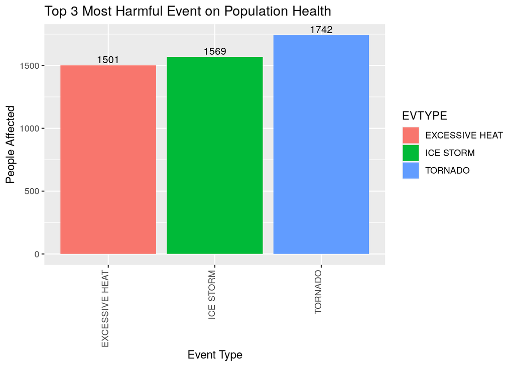

```r
ggplot(StormMaxValue, aes(EVTYPE,TOTALHEALTHDMG, fill = EVTYPE)) +
    geom_bar(position = "dodge",stat="identity") +
    geom_text(aes(label=TOTALHEALTHDMG), vjust=-0.3, size=3.5) +
    labs(x = "Event Type", y = "People Affected") +
    labs(title = "Top 3 Most Harmful Event on Population Health") +
    theme(axis.text.x = element_text(angle = 90, hjust = 1, vjust = 0))
```

### Analysis:

The plot shows that tornado is the most harmful event type regarding to population health (FATALITIES and INJURIES) in the United States.

### Based on that,an Aggregation Table is generated:

```r
StormECAgg <- aggregate(PROPDMG~EVTYPE + CROPDMG, StormData, sum, na.rm = TRUE)
StormECAgg$TOTALPROPDMG <- StormECAgg$PROPDMG + StormECAgg$CROPDMG
# ORDERING VALUES
OrderedStormECDat <- StormECAgg[order(-StormECAgg$TOTALPROPDMG),]
StormECMaxValue <- head(OrderedStormECDat,6)
```

### The Resulting Plot:

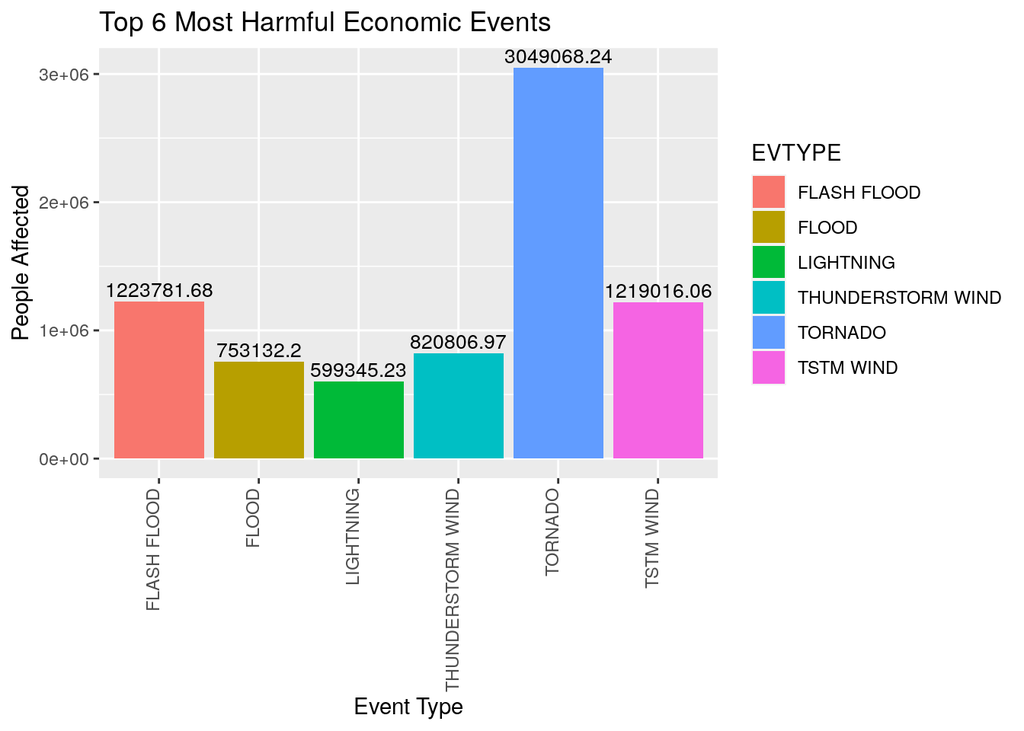

```r
ggplot(StormECMaxValue, aes(EVTYPE,TOTALPROPDMG, fill = EVTYPE)) +
    geom_bar(position = "dodge",stat="identity") +
    geom_text(aes(label=TOTALPROPDMG), vjust=-0.3, size=3.5) +
    labs(x = "Event Type", y = "People Affected") +
    labs(title = "Top 6 Most Harmful Economic Events") +
    theme(axis.text.x = element_text(angle = 90, hjust = 1, vjust = 0))
```

### Analysis:

The plot shows that tornados is the most harmful event type regarding to economics (Property and crop damages) in the United States.